# Assignment5_SparkDF_PandasDF

Install Spark

```python
# Update environment (if needed)
# !sudo apt update

# Download and install Java
!sudo apt-get install openjdk-8-jdk-headless -qq > /dev/null

# Install Apache Spark with Hadoop
!wget -nc -q https://downloads.apache.org/spark/spark-3.5.1/spark-3.5.1-bin-hadoop3.tgz

# Unzip the folder
!tar xf spark-3.5.1-bin-hadoop3.tgz

# Install findspark library that will locate Spark on the system
!pip install -q findspark
```

```python
# Setting the environment variables, to enable running PySpark in Colab environment.

import os
import shutil
from itertools import islice
import requests

os.environ["JAVA_HOME"] = "/usr/lib/jvm/java-8-openjdk-amd64"
os.environ["SPARK_HOME"] = "/content/spark-3.5.1-bin-hadoop3"
```

```python
# Locate Spark in the system

import findspark
findspark.init()
```

Import SparkSession and SparkSQL

```python
from pyspark.sql import SparkSession
from pyspark.sql.functions import *
# from pyspark.sql import functions as F
from pyspark.sql.types import *

# Create spark_session
spark = SparkSession.builder.getOrCreate()
sc = spark.sparkContext

spark.version
```

```
'3.5.1'
```

```python
from pyspark.sql import SparkSession
from pyspark.sql import functions as F
```

Mount Google drive, we will be using GDrive for processing

Files will be present in "/content/drive/My Drive".

```python
# Load the Drive helper and mount
from google.colab import drive

# This will prompt for authorization.
drive.mount('/content/drive')
```

Set-up helper functions

```python
import os
import shutil
from itertools import islice
import requests
import pandas as pd

import matplotlib.pyplot as plt

pd.set_option("max_colwidth", 100)
```

```python
def list_files(dir_name):
    try:
        list_of_files = [file_name for file_name in os.listdir(dir_name) if os.path.isfile(os.path.join(dir_name, file_name))]
        files_with_size = [ (file_name, os.stat(os.path.join(dir_name, file_name)).st_size)
                    for file_name in list_of_files if not file_name.startswith('.')]
        for file_name, size in files_with_size:
            print(file_name, ' -->', size)
    except OSError as e:
        print("Error: %s : %s" % (dir_name, e.strerror))
```

```python
def delete_folder(dir_name):
    try:
        shutil.rmtree(dir_name)
    except OSError as e:
        print("Error: %s : %s" % (dir_name, e.strerror))
```

Pull source data from GCS into Colab

```python
def get_gcs_data (bucket_name, folder_name, file_name, path_gdrive):
    url = 'https://storage.googleapis.com/' + bucket_name + '/' + folder_name + '/' + file_name
    r = requests.get(url)
    open(path_gdrive + '/' + file_name , 'wb').write(r.content)
```

```python
bucket_name = 'msca-bdp-data-open'
folder_name = 'airlines'
file_name = ['2007.csv', '2008.csv']
path_gdrive = '/content/drive/My Drive/Colab Datasets/BDP/airlines'

os.makedirs(path_gdrive, exist_ok=True)

for file in file_name:
    get_gcs_data (bucket_name = bucket_name,
                 folder_name = folder_name,
                 file_name = file,
                 path_gdrive = path_gdrive)
    print('Downloaded: ' + file)
```

```
Downloaded: 2007.csv
Downloaded: 2008.csv
```

```python
list_files(path_gdrive)
```

```
2007.csv  --> 702878193
2008.csv  --> 689413344
```

```python
path2007 = path_gdrive+'/2007.csv'
```

```python
path2008 = path_gdrive+'/2008.csv'
```

Spark Dataframe

```python
airlines_2007 = spark.read.csv(path2007, header='true', inferSchema='true', sep=',', quote='"')

airlines_2007.cache()

# inferSchema='true' to guess the type of data
```

| Year | Month | DayofMonth | DayOfWeek | DepTime | CRSDepTime | ArrTime | CRSArrTime | UniqueCarrier | FlightNum | TailNum | ActualElapsedTime | CRSElapsedTime | AirTime | ArrDelay | DepDelay | Origin | Dest | Distance | TaxiIn | TaxiOut | Cancelled | CancellationCode | Diverted | CarrierDelay | WeatherDelay | NASDelay | SecurityDelay | LateAircraftDelay |
| --- | --- | --- | --- | --- | --- | --- | --- | --- | --- | --- | --- | --- | --- | --- | --- | --- | --- | --- | --- | --- | --- | --- | --- | --- | --- | --- | --- | --- |
| 2007 | 1 | 1 | 1 | 1232 | 1225 | 1341 | 1340 | WN | 2891 | N351 | 69 | 75 | 54 | 1 | 7 | SMF | ONT | 389 | 4 | 11 | 0 | NULL | 0 | 0 | 0 | 0 | 0 | 0 |
| 2007 | 1 | 1 | 1 | 1918 | 1905 | 2043 | 2035 | WN | 462 | N370 | 85 | 90 | 74 | 8 | 13 | SMF | PDX | 479 | 5 | 6 | 0 | NULL | 0 | 0 | 0 | 0 | 0 | 0 |
| 2007 | 1 | 1 | 1 | 2206 | 2130 | 2334 | 2300 | WN | 1229 | N685 | 88 | 90 | 73 | 34 | 36 | SMF | PDX | 479 | 6 | 9 | 0 | NULL | 0 | 3 | 0 | 0 | 0 | 31 |
| 2007 | 1 | 1 | 1 | 1230 | 1200 | 1356 | 1330 | WN | 1355 | N364 | 86 | 90 | 75 | 26 | 30 | SMF | PDX | 479 | 3 | 8 | 0 | NULL | 0 | 23 | 0 | 0 | 0 | 3 |
| 2007 | 1 | 1 | 1 | 831 | 830 | 957 | 1000 | WN | 2278 | N480 | 86 | 90 | 74 | -3 | 1 | SMF | PDX | 479 | 3 | 9 | 0 | NULL | 0 | 0 | 0 | 0 | 0 | 0 |
| 2007 | 1 | 1 | 1 | 1430 | 1420 | 1553 | 1550 | WN | 2386 | N611SW | 83 | 90 | 74 | 3 | 10 | SMF | PDX | 479 | 2 | 7 | 0 | NULL | 0 | 0 | 0 | 0 | 0 | 0 |
| 2007 | 1 | 1 | 1 | 1936 | 1840 | 2217 | 2130 | WN | 409 | N482 | 101 | 110 | 89 | 47 | 56 | SMF | PHX | 647 | 5 | 7 | 0 | NULL | 0 | 46 | 0 | 0 | 0 | 1 |
| 2007 | 1 | 1 | 1 | 944 | 935 | 1223 | 1225 | WN | 1131 | N749SW | 99 | 110 | 86 | -2 | 9 | SMF | PHX | 647 | 4 | 9 | 0 | NULL | 0 | 0 | 0 | 0 | 0 | 0 |
| 2007 | 1 | 1 | 1 | 1537 | 1450 | 1819 | 1735 | WN | 1212 | N451 | 102 | 105 | 90 | 44 | 47 | SMF | PHX | 647 | 5 | 7 | 0 | NULL | 0 | 20 | 0 | 0 | 0 | 24 |
| 2007 | 1 | 1 | 1 | 1318 | 1315 | 1603 | 1610 | WN | 2456 | N630WN | 105 | 115 | 92 | -7 | 3 | SMF | PHX | 647 | 5 | 8 | 0 | NULL | 0 | 0 | 0 | 0 | 0 | 0 |
| 2007 | 1 | 1 | 1 | 836 | 835 | 1119 | 1130 | WN | 2575 | N493 | 103 | 115 | 88 | -11 | 1 | SMF | PHX | 647 | 7 | 8 | 0 | NULL | 0 | 0 | 0 | 0 | 0 | 0 |
| 2007 | 1 | 1 | 1 | 2047 | 1955 | 2332 | 2240 | WN | 2608 | N733SW | 105 | 105 | 89 | 52 | 52 | SMF | PHX | 647 | 7 | 9 | 0 | NULL | 0 | 49 | 0 | 0 | 0 | 3 |
| 2007 | 1 | 1 | 1 | 2128 | 2035 | 2245 | 2200 | WN | 139 | N348 | 77 | 85 | 66 | 45 | 53 | SMF | SAN | 480 | 3 | 8 | 0 | NULL | 0 | 0 | 0 | 3 | 0 | 42 |
| 2007 | 1 | 1 | 1 | 935 | 940 | 1048 | 1105 | WN | 747 | N358 | 73 | 85 | 63 | -17 | -5 | SMF | SAN | 480 | 2 | 8 | 0 | NULL | 0 | 0 | 0 | 0 | 0 | 0 |
| 2007 | 1 | 1 | 1 | 1251 | 1245 | 1405 | 1410 | WN | 933 | N413 | 74 | 85 | 65 | -5 | 6 | SMF | SAN | 480 | 2 | 7 | 0 | NULL | 0 | 0 | 0 | 0 | 0 | 0 |
| 2007 | 1 | 1 | 1 | 1729 | 1645 | 1843 | 1810 | WN | 1054 | N416 | 74 | 85 | 64 | 33 | 44 | SMF | SAN | 480 | 3 | 7 | 0 | NULL | 0 | 3 | 0 | 0 | 0 | 30 |
| 2007 | 1 | 1 | 1 | 825 | 825 | 941 | 950 | WN | 1106 | N383SW | 76 | 85 | 63 | -9 | 0 | SMF | SAN | 480 | 3 | 10 | 0 | NULL | 0 | 0 | 0 | 0 | 0 | 0 |
| 2007 | 1 | 1 | 1 | 1042 | 1040 | 1158 | 1205 | WN | 1554 | N316SW | 76 | 85 | 66 | -7 | 2 | SMF | SAN | 480 | 2 | 8 | 0 | NULL | 0 | 0 | 0 | 0 | 0 | 0 |
| 2007 | 1 | 1 | 1 | 1726 | 1725 | 1839 | 1850 | WN | 1604 | N691WN | 73 | 85 | 63 | -11 | 1 | SMF | SAN | 480 | 3 | 7 | 0 | NULL | 0 | 0 | 0 | 0 | 0 | 0 |
| 2007 | 1 | 1 | 1 | 1849 | 1820 | 2016 | 1940 | WN | 1975 | N308SW | 87 | 80 | 69 | 36 | 29 | SMF | SAN | 480 | 3 | 15 | 0 | NULL | 0 | 20 | 0 | 7 | 0 | 9 |

only showing top 20 rows

```python
airlines_2008 = spark.read.csv(path2008, header='true', inferSchema='true', sep=',', quote='"')

airlines_2008.cache()
```

| Year | Month | DayofMonth | DayOfWeek | DepTime | CRSDepTime | ArrTime | CRSArrTime | UniqueCarrier | FlightNum | TailNum | ActualElapsedTime | CRSElapsedTime | AirTime | ArrDelay | DepDelay | Origin | Dest | Distance | TaxiIn | TaxiOut | Cancelled | CancellationCode | Diverted | CarrierDelay | WeatherDelay | NASDelay | SecurityDelay | LateAircraftDelay |
| --- | --- | --- | --- | --- | --- | --- | --- | --- | --- | --- | --- | --- | --- | --- | --- | --- | --- | --- | --- | --- | --- | --- | --- | --- | --- | --- | --- | --- |
| 2008 | 1 | 3 | 4 | 2003 | 1955 | 2211 | 2225 | WN | 335 | N712SW | 128 | 150 | 116 | -14 | 8 | IAD | TPA | 810 | 4 | 8 | 0 | NULL | 0 | NA | NA | NA | NA | NA |
| 2008 | 1 | 3 | 4 | 754 | 735 | 1002 | 1000 | WN | 3231 | N772SW | 128 | 145 | 113 | 2 | 19 | IAD | TPA | 810 | 5 | 10 | 0 | NULL | 0 | NA | NA | NA | NA | NA |
| 2008 | 1 | 3 | 4 | 628 | 620 | 804 | 750 | WN | 448 | N428WN | 96 | 90 | 76 | 14 | 8 | IND | BWI | 515 | 3 | 17 | 0 | NULL | 0 | NA | NA | NA | NA | NA |
| 2008 | 1 | 3 | 4 | 926 | 930 | 1054 | 1100 | WN | 1746 | N612SW | 88 | 90 | 78 | -6 | -4 | IND | BWI | 515 | 3 | 7 | 0 | NULL | 0 | NA | NA | NA | NA | NA |
| 2008 | 1 | 3 | 4 | 1829 | 1755 | 1959 | 1925 | WN | 3920 | N464WN | 90 | 90 | 77 | 34 | 34 | IND | BWI | 515 | 3 | 10 | 0 | NULL | 0 | 2 | 0 | 0 | 0 | 32 |
| 2008 | 1 | 3 | 4 | 1940 | 1915 | 2121 | 2110 | WN | 378 | N726SW | 101 | 115 | 87 | 11 | 25 | IND | JAX | 688 | 4 | 10 | 0 | NULL | 0 | NA | NA | NA | NA | NA |
| 2008 | 1 | 3 | 4 | 1937 | 1830 | 2037 | 1940 | WN | 509 | N763SW | 240 | 250 | 230 | 57 | 67 | IND | LAS | 1591 | 3 | 7 | 0 | NULL | 0 | 10 | 0 | 0 | 0 | 47 |
| 2008 | 1 | 3 | 4 | 1039 | 1040 | 1132 | 1150 | WN | 535 | N428WN | 233 | 250 | 219 | -18 | -1 | IND | LAS | 1591 | 7 | 7 | 0 | NULL | 0 | NA | NA | NA | NA | NA |
| 2008 | 1 | 3 | 4 | 617 | 615 | 652 | 650 | WN | 11 | N689SW | 95 | 95 | 70 | 2 | 2 | IND | MCI | 451 | 6 | 19 | 0 | NULL | 0 | NA | NA | NA | NA | NA |
| 2008 | 1 | 3 | 4 | 1620 | 1620 | 1639 | 1655 | WN | 810 | N648SW | 79 | 95 | 70 | -16 | 0 | IND | MCI | 451 | 3 | 6 | 0 | NULL | 0 | NA | NA | NA | NA | NA |
| 2008 | 1 | 3 | 4 | 706 | 700 | 916 | 915 | WN | 100 | N690SW | 130 | 135 | 106 | 1 | 6 | IND | MCO | 828 | 5 | 19 | 0 | NULL | 0 | NA | NA | NA | NA | NA |
| 2008 | 1 | 3 | 4 | 1644 | 1510 | 1845 | 1725 | WN | 1333 | N334SW | 121 | 135 | 107 | 80 | 94 | IND | MCO | 828 | 6 | 8 | 0 | NULL | 0 | 8 | 0 | 0 | 0 | 72 |
| 2008 | 1 | 3 | 4 | 1426 | 1430 | 1426 | 1425 | WN | 829 | N476WN | 60 | 55 | 39 | 1 | -4 | IND | MDW | 162 | 9 | 12 | 0 | NULL | 0 | NA | NA | NA | NA | NA |
| 2008 | 1 | 3 | 4 | 715 | 715 | 720 | 710 | WN | 1016 | N765SW | 65 | 55 | 37 | 10 | 0 | IND | MDW | 162 | 7 | 21 | 0 | NULL | 0 | NA | NA | NA | NA | NA |
| 2008 | 1 | 3 | 4 | 1702 | 1700 | 1651 | 1655 | WN | 1827 | N420WN | 49 | 55 | 35 | -4 | 2 | IND | MDW | 162 | 4 | 10 | 0 | NULL | 0 | NA | NA | NA | NA | NA |
| 2008 | 1 | 3 | 4 | 1029 | 1020 | 1021 | 1010 | WN | 2272 | N263WN | 52 | 50 | 37 | 11 | 9 | IND | MDW | 162 | 6 | 9 | 0 | NULL | 0 | NA | NA | NA | NA | NA |
| 2008 | 1 | 3 | 4 | 1452 | 1425 | 1640 | 1625 | WN | 675 | N286WN | 228 | 240 | 213 | 15 | 27 | IND | PHX | 1489 | 7 | 8 | 0 | NULL | 0 | 3 | 0 | 0 | 0 | 12 |
| 2008 | 1 | 3 | 4 | 754 | 745 | 940 | 955 | WN | 1144 | N778SW | 226 | 250 | 205 | -15 | 9 | IND | PHX | 1489 | 5 | 16 | 0 | NULL | 0 | NA | NA | NA | NA | NA |
| 2008 | 1 | 3 | 4 | 1323 | 1255 | 1526 | 1510 | WN | 4 | N674AA | 123 | 135 | 110 | 16 | 28 | IND | TPA | 838 | 4 | 9 | 0 | NULL | 0 | 0 | 0 | 0 | 0 | 16 |
| 2008 | 1 | 3 | 4 | 1416 | 1325 | 1512 | 1435 | WN | 54 | N643SW | 56 | 70 | 49 | 37 | 51 | ISP | BWI | 220 | 2 | 5 | 0 | NULL | 0 | 12 | 0 | 0 | 0 | 25 |

only showing top 20 rows

```python
type(airlines_2007)
```

```
pyspark.sql.dataframe.DataFrame
def __init__(jdf: JavaObject, sql_ctx: Union['SQLContext', 'SparkSession'])
```

[output not shown]

```python
airlines_2007.first()
```

```
Row(Year=2007, Month=1, DayofMonth=1, DayOfWeek=1, DepTime='1232', CRSDepTime=1225, ArrTime='1341', CRSArrTime=1340, UniqueCarrier='WN', FlightNum=2891, TailNum='N351', ActualElapsedTime='69', CRSElapsedTime='75', AirTime='54', ArrDelay='1', DepDelay='7', Origin='SMF', Dest='ONT', Distance=389, Taxi…
```

```python
airlines_2007.show(5)
```

```
+----+-----+----------+---------+-------+----------+-------+----------+-------------+---------+-------+-----------------+--------------+-------+--------+--------+------+----+--------+------+-------+---------+----------------+--------+------------+------------+--------+-------------+-----------------…
|Year|Month|DayofMonth|DayOfWeek|DepTime|CRSDepTime|ArrTime|CRSArrTime|UniqueCarrier|FlightNum|TailNum|ActualElapsedTime|CRSElapsedTime|AirTime|ArrDelay|DepDelay|Origin|Dest|Distance|TaxiIn|TaxiOut|Cancelled|CancellationCode|Diverted|CarrierDelay|WeatherDelay|NASDelay|SecurityDelay|LateAircraftDelay…
+----+-----+----------+---------+-------+----------+-------+----------+-------------+---------+-------+-----------------+--------------+-------+--------+--------+------+----+--------+------+-------+---------+----------------+--------+------------+------------+--------+-------------+-----------------…
|2007|    1|         1|        1|   1232|      1225|   1341|      1340|           WN|     2891|   N351|               69|            75|     54|       1|       7|   SMF| ONT|     389|     4|     11|        0|            NULL|       0|           0|           0|       0|            0|                0…
|2007|    1|         1|        1|   1918|      1905|   2043|      2035|           WN|      462|   N370|               85|            90|     74|       8|      13|   SMF| PDX|     479|     5|      6|        0|            NULL|       0|           0|           0|       0|            0|                0…
|2007|    1|         1|        1|   2206|      2130|   2334|      2300|           WN|     1229|   N685|               88|            90|     73|      34|      36|   SMF| PDX|     479|     6|      9|        0|            NULL|       0|           3|           0|       0|            0|               31…
|2007|    1|         1|        1|   1230|      1200|   1356|      1330|           WN|     1355|   N364|               86|            90|     75|      26|      30|   SMF| PDX|     479|     3|      8|        0|            NULL|       0|          23|           0|       0|            0|                3…
|2007|    1|         1|        1|    831|       830|    957|      1000|           WN|     2278|   N480|               86|            90|     74|      -3|       1|   SMF| PDX|     479|     3|      9|        0|            NULL|       0|           0|           0|       0|            0|                0…
+----+-----+----------+---------+-------+----------+-------+----------+-------------+---------+-------+-----------------+--------------+-------+--------+--------+------+----+--------+------+-------+---------+----------------+--------+------------+------------+--------+-------------+-----------------…
only showing top 5 rows
```

Enable repl.eagerEval - very important ?!

This will output the results of DataFrames in each step without the need to use df.show() and also improves the formatting of the output

```python
spark.conf.set("spark.sql.repl.eagerEval.enabled",True) # enable it once
```

```python
airlines_2007.limit(5)
```

| Year | Month | DayofMonth | DayOfWeek | DepTime | CRSDepTime | ArrTime | CRSArrTime | UniqueCarrier | FlightNum | TailNum | ActualElapsedTime | CRSElapsedTime | AirTime | ArrDelay | DepDelay | Origin | Dest | Distance | TaxiIn | TaxiOut | Cancelled | CancellationCode | Diverted | CarrierDelay | WeatherDelay | NASDelay | SecurityDelay | LateAircraftDelay |
| --- | --- | --- | --- | --- | --- | --- | --- | --- | --- | --- | --- | --- | --- | --- | --- | --- | --- | --- | --- | --- | --- | --- | --- | --- | --- | --- | --- | --- |
| 2007 | 1 | 1 | 1 | 1232 | 1225 | 1341 | 1340 | WN | 2891 | N351 | 69 | 75 | 54 | 1 | 7 | SMF | ONT | 389 | 4 | 11 | 0 | NULL | 0 | 0 | 0 | 0 | 0 | 0 |
| 2007 | 1 | 1 | 1 | 1918 | 1905 | 2043 | 2035 | WN | 462 | N370 | 85 | 90 | 74 | 8 | 13 | SMF | PDX | 479 | 5 | 6 | 0 | NULL | 0 | 0 | 0 | 0 | 0 | 0 |
| 2007 | 1 | 1 | 1 | 2206 | 2130 | 2334 | 2300 | WN | 1229 | N685 | 88 | 90 | 73 | 34 | 36 | SMF | PDX | 479 | 6 | 9 | 0 | NULL | 0 | 3 | 0 | 0 | 0 | 31 |
| 2007 | 1 | 1 | 1 | 1230 | 1200 | 1356 | 1330 | WN | 1355 | N364 | 86 | 90 | 75 | 26 | 30 | SMF | PDX | 479 | 3 | 8 | 0 | NULL | 0 | 23 | 0 | 0 | 0 | 3 |
| 2007 | 1 | 1 | 1 | 831 | 830 | 957 | 1000 | WN | 2278 | N480 | 86 | 90 | 74 | -3 | 1 | SMF | PDX | 479 | 3 | 9 | 0 | NULL | 0 | 0 | 0 | 0 | 0 | 0 |

```python
airlines_2008.limit(5)
```

| Year | Month | DayofMonth | DayOfWeek | DepTime | CRSDepTime | ArrTime | CRSArrTime | UniqueCarrier | FlightNum | TailNum | ActualElapsedTime | CRSElapsedTime | AirTime | ArrDelay | DepDelay | Origin | Dest | Distance | TaxiIn | TaxiOut | Cancelled | CancellationCode | Diverted | CarrierDelay | WeatherDelay | NASDelay | SecurityDelay | LateAircraftDelay |
| --- | --- | --- | --- | --- | --- | --- | --- | --- | --- | --- | --- | --- | --- | --- | --- | --- | --- | --- | --- | --- | --- | --- | --- | --- | --- | --- | --- | --- |
| 2008 | 1 | 3 | 4 | 2003 | 1955 | 2211 | 2225 | WN | 335 | N712SW | 128 | 150 | 116 | -14 | 8 | IAD | TPA | 810 | 4 | 8 | 0 | NULL | 0 | NA | NA | NA | NA | NA |
| 2008 | 1 | 3 | 4 | 754 | 735 | 1002 | 1000 | WN | 3231 | N772SW | 128 | 145 | 113 | 2 | 19 | IAD | TPA | 810 | 5 | 10 | 0 | NULL | 0 | NA | NA | NA | NA | NA |
| 2008 | 1 | 3 | 4 | 628 | 620 | 804 | 750 | WN | 448 | N428WN | 96 | 90 | 76 | 14 | 8 | IND | BWI | 515 | 3 | 17 | 0 | NULL | 0 | NA | NA | NA | NA | NA |
| 2008 | 1 | 3 | 4 | 926 | 930 | 1054 | 1100 | WN | 1746 | N612SW | 88 | 90 | 78 | -6 | -4 | IND | BWI | 515 | 3 | 7 | 0 | NULL | 0 | NA | NA | NA | NA | NA |
| 2008 | 1 | 3 | 4 | 1829 | 1755 | 1959 | 1925 | WN | 3920 | N464WN | 90 | 90 | 77 | 34 | 34 | IND | BWI | 515 | 3 | 10 | 0 | NULL | 0 | 2 | 0 | 0 | 0 | 32 |

```python
airlines_2007.printSchema()
```

```
root
 |-- Year: integer (nullable = true)
 |-- Month: integer (nullable = true)
 |-- DayofMonth: integer (nullable = true)
 |-- DayOfWeek: integer (nullable = true)
 |-- DepTime: string (nullable = true)
 |-- CRSDepTime: integer (nullable = true)
 |-- ArrTime: string (nullable = true)
 |-- CRSArrTime: integer (nullable = true)
 |-- UniqueCarrier: string (nullable = true)
 |-- FlightNum: integer (nullable = true)
 |-- TailNum: string (nullable = true)
 |-- ActualElapsedTime: string (nullable = true)
 |-- CRSElapsedTime: string (nullable = true)
 |-- AirTime: string (nullable = true)
 |-- ArrDelay: string (nullable = true)
 |-- DepDelay: string (nullable = true)
 |-- Origin: string (nullable = true)
 |-- Dest: string (nullable = true)
 |-- Distance: integer (nullable = true)
 |-- TaxiIn: integer (nullable = true)
 |-- TaxiOut: integer (nullable = true)
 |-- Cancelled: integer (nullable = true)
 |-- CancellationCode: string (nullable = true)
 |-- Diverted: integer (nullable = true)
 |-- CarrierDelay: integer (nullable = true)
 |-- WeatherDelay: integer (nullable = true)
 |-- NASDelay: integer (nullable = true)
 |-- SecurityDelay: integer (nullable = true)
 |-- LateAircraftDelay: integer (nullable = true)
```

```python
airlines_2008.printSchema()
```

```
root
 |-- Year: integer (nullable = true)
 |-- Month: integer (nullable = true)
 |-- DayofMonth: integer (nullable = true)
 |-- DayOfWeek: integer (nullable = true)
 |-- DepTime: string (nullable = true)
 |-- CRSDepTime: integer (nullable = true)
 |-- ArrTime: string (nullable = true)
 |-- CRSArrTime: integer (nullable = true)
 |-- UniqueCarrier: string (nullable = true)
 |-- FlightNum: integer (nullable = true)
 |-- TailNum: string (nullable = true)
 |-- ActualElapsedTime: string (nullable = true)
 |-- CRSElapsedTime: string (nullable = true)
 |-- AirTime: string (nullable = true)
 |-- ArrDelay: string (nullable = true)
 |-- DepDelay: string (nullable = true)
 |-- Origin: string (nullable = true)
 |-- Dest: string (nullable = true)
 |-- Distance: integer (nullable = true)
 |-- TaxiIn: string (nullable = true)
 |-- TaxiOut: string (nullable = true)
 |-- Cancelled: integer (nullable = true)
 |-- CancellationCode: string (nullable = true)
 |-- Diverted: integer (nullable = true)
 |-- CarrierDelay: string (nullable = true)
 |-- WeatherDelay: string (nullable = true)
 |-- NASDelay: string (nullable = true)
 |-- SecurityDelay: string (nullable = true)
 |-- LateAircraftDelay: string (nullable = true)
```

```python
# Variable casting

airlines_2007 = airlines_2007.withColumn("ArrDelay", airlines_2007["ArrDelay"].cast(IntegerType()))
airlines_2007 = airlines_2007.withColumn("DepDelay", airlines_2007["DepDelay"].cast(IntegerType()))
airlines_2008 = airlines_2008.withColumn("ArrDelay", airlines_2008["ArrDelay"].cast(IntegerType()))
airlines_2008 = airlines_2008.withColumn("DepDelay", airlines_2008["DepDelay"].cast(IntegerType()))
```

```python
# airlines_2007.describe()
```

# 1. Which locations (Origin and Dest pairs) had the worst delays for both arrivals (ArrDelay) and departures (DepDelay) - for each year

```python
delays_2007_df = airlines_2007.groupBy('Origin', 'Dest') \
    .agg(F.avg('ArrDelay').alias('AvgArrDelay'), F.avg('DepDelay').alias('AvgDepDelay'))
```

```python
delays_2008_df = airlines_2008.groupBy('Origin', 'Dest') \
    .agg(F.avg('ArrDelay').alias('AvgArrDelay'), F.avg('DepDelay').alias('AvgDepDelay'))
```

```python
# In 2007, worst ArrDelay for Origin and Dest pairs

delays_2007_df.orderBy('AvgArrDelay', ascending=False).select\
(["Origin", "Dest", "AvgArrDelay"]).limit(5)
```

| Origin | Dest | AvgArrDelay |
| --- | --- | --- |
| ONT | IAD | 370.0 |
| ELP | MFE | 316.0 |
| ACY | MYR | 252.0 |
| JAX | CMH | 217.0 |
| DCA | PLN | 210.0 |

```python
# In 2007, worst DepDelay for Origin and Dest pairs

delays_2007_df.orderBy('AvgDepDelay', ascending=False).select\
(["Origin", "Dest", "AvgDepDelay"]).limit(5)
```

| Origin | Dest | AvgDepDelay |
| --- | --- | --- |
| ONT | IAD | 386.0 |
| ABQ | GJT | 366.0 |
| RAP | TWF | 347.0 |
| ELP | MFE | 307.0 |
| OKC | GJT | 270.0 |

```python
# In 2008, worst ArrDelay for Origin and Dest pairs

delays_2008_df.orderBy('AvgArrDelay', ascending=False).select\
(["Origin", "Dest", "AvgArrDelay"]).limit(5)
```

| Origin | Dest | AvgArrDelay |
| --- | --- | --- |
| CMI | SPI | 575.0 |
| ONT | SAN | 257.0 |
| BHM | JFK | 252.0 |
| RIC | ORF | 227.0 |
| ATW | DSM | 210.0 |

```python
# In 2008, worst DepDelay for Origin and Dest pairs

delays_2008_df.orderBy('AvgDepDelay', ascending=False).select\
(["Origin", "Dest", "AvgDepDelay"]).limit(5)
```

| Origin | Dest | AvgDepDelay |
| --- | --- | --- |
| CMI | SPI | 587.0 |
| SDF | SPI | 329.0 |
| HPN | PIA | 298.0 |
| TUL | PIA | 243.0 |
| ONT | SAN | 221.0 |

```python
type(delays_2008_df)
```

```
pyspark.sql.dataframe.DataFrame
def __init__(jdf: JavaObject, sql_ctx: Union['SQLContext', 'SparkSession'])
```

[output not shown]

# 2. Which locations (Origin and Dest pairs) had the fewest delays for both arrivals (ArrDelay) and departures (DepDelay) - for each year

```python
# In 2007, fewest ArrDelay for Origin and Dest pairs

delays_2007_df.orderBy('AvgArrDelay', ascending=True).select\
(["Origin", "Dest", "AvgArrDelay"]).limit(20)
```

| Origin | Dest | AvgArrDelay |
| --- | --- | --- |
| ELP | GJT | NULL |
| HDN | PIH | NULL |
| CID | COS | NULL |
| CEC | SMF | NULL |
| HLN | PIH | NULL |
| PSP | GJT | NULL |
| ICT | PIA | NULL |
| COS | RFD | NULL |
| LAS | PIH | NULL |
| RAP | TWF | NULL |
| RAP | PIH | NULL |
| BOI | TWF | NULL |
| RFD | COS | NULL |
| LAX | CDC | NULL |
| SGU | TWF | NULL |
| MEM | PIA | NULL |
| SNA | BFL | NULL |
| DSM | PIH | NULL |
| BTV | MCO | NULL |
| FCA | PIH | NULL |

```python
# In 2007, fewest DepDelay for Origin and Dest pairs

delays_2007_df.orderBy('AvgDepDelay', ascending=True).select\
(["Origin", "Dest", "AvgDepDelay"]).limit(20)
```

| Origin | Dest | AvgDepDelay |
| --- | --- | --- |
| SBP | SMX | NULL |
| MCI | OMA | NULL |
| MIA | FLL | NULL |
| TVC | MQT | NULL |
| TLH | JAX | NULL |
| OKC | TUL | NULL |
| SEA | EUG | NULL |
| BUR | LAX | NULL |
| ONT | SBA | NULL |
| SMF | FAT | NULL |
| SDF | JAX | -85.0 |
| SAT | AUS | -55.0 |
| RDM | SMF | -22.0 |
| BDL | BOS | -20.0 |
| COS | TUL | -16.0 |
| LAX | SDF | -16.0 |
| ILM | RDU | -15.0 |
| ELP | COS | -14.0 |
| MSN | PUB | -13.0 |
| MKE | MDW | -12.0 |

```python
# In 2008, fewest ArrDelay for Origin and Dest pairs

delays_2008_df.orderBy('AvgArrDelay', ascending=True).select\
(["Origin", "Dest", "AvgArrDelay"]).limit(20)
```

| Origin | Dest | AvgArrDelay |
| --- | --- | --- |
| OMA | COS | NULL |
| ICT | PIA | NULL |
| COS | LAN | NULL |
| TUL | OKC | NULL |
| PSP | GJT | NULL |
| SJC | FAT | NULL |
| MOD | RNO | NULL |
| IYK | BFL | NULL |
| BWI | GRR | NULL |
| BHM | MKE | NULL |
| CLT | ATW | NULL |
| EUG | MFR | NULL |
| SDF | SPI | NULL |
| ALB | SBN | NULL |
| DSM | GJT | NULL |
| RDU | GRB | NULL |
| SAT | AMA | NULL |
| ACV | MRY | NULL |
| GEG | RDM | NULL |
| SLE | TWF | NULL |

```python
# In 2008, fewest DepDelay for Origin and Dest pairs

delays_2008_df.orderBy('AvgDepDelay', ascending=True).select\
(["Origin", "Dest", "AvgDepDelay"]).limit(20)
```

| Origin | Dest | AvgDepDelay |
| --- | --- | --- |
| TUL | XNA | NULL |
| ASE | GJT | NULL |
| FLL | MIA | NULL |
| AUS | ORF | NULL |
| EWR | LGA | NULL |
| CID | DSM | NULL |
| OAK | SMF | NULL |
| AVP | HPN | NULL |
| PHL | AVP | NULL |
| SFO | SJC | NULL |
| MKE | TUS | -36.5 |
| OMA | LNK | -34.0 |
| SUN | TWF | -29.0 |
| BUR | RNO | -26.0 |
| FSD | SDF | -25.0 |
| ATW | CHS | -23.0 |
| HPN | PIT | -22.0 |
| TYS | MCI | -19.0 |
| BOS | BTV | -18.0 |
| LIT | SAT | -15.0 |

# 3. Do you see any significant seasonality effects for delays?

# Answer: summer and holiday seasons have worst delays.

```python
# Analyze seasonality effects for delays by grouping data by Month

seasonality_2007_df = airlines_2007.groupBy('Month') \
    .agg(F.avg('ArrDelay').alias('AvgArrDelay'), F.avg('DepDelay').alias('AvgDepDelay')) \
    .orderBy('Month')
seasonality_2007_df
```

| Month | AvgArrDelay | AvgDepDelay |
| --- | --- | --- |
| 1 | 9.162151701506165 | 10.286743415948312 |
| 2 | 13.51979483296776 | 14.02253123732965 |
| 3 | 10.084908470559062 | 11.836802542694253 |
| 4 | 8.516229825822615 | 10.07771370814071 |
| 5 | 7.037888681043307 | 8.329205401044868 |
| 6 | 16.17952800579826 | 16.214701071994014 |
| 7 | 14.107679837700504 | 14.802613636005757 |
| 8 | 12.57153344196042 | 13.515875591278409 |
| 9 | 3.7494980749698845 | 6.157685958765665 |
| 10 | 6.5082592714725775 | 7.973724233737243 |
| 11 | 4.793344024722863 | 7.446888306310218 |
| 12 | 16.213714049846818 | 16.201398473962534 |

```python
seasonality_2007_df.printSchema()
```

```
root
 |-- Month: integer (nullable = true)
 |-- AvgArrDelay: double (nullable = true)
 |-- AvgDepDelay: double (nullable = true)
```

```python
# Convert Spark DataFrame to Pandas DataFrame
seasonality_2007_pd = seasonality_2007_df.toPandas()
```

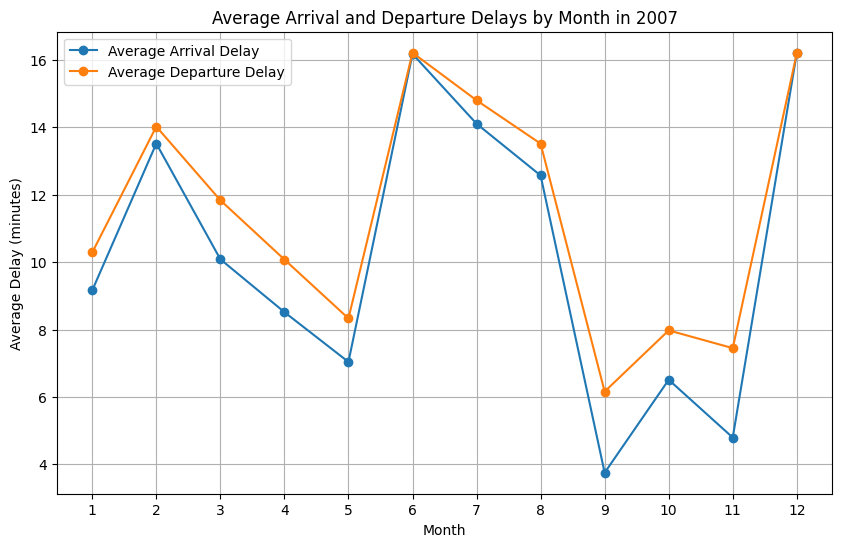

```python
# Plotting
plt.figure(figsize=(10, 6))
plt.plot(seasonality_2007_pd['Month'], seasonality_2007_pd['AvgArrDelay'], label='Average Arrival Delay', marker='o')
plt.plot(seasonality_2007_pd['Month'], seasonality_2007_pd['AvgDepDelay'], label='Average Departure Delay', marker='o')
plt.title('Average Arrival and Departure Delays by Month in 2007')
plt.xlabel('Month')
plt.ylabel('Average Delay (minutes)')
plt.xticks(range(1, 13))
plt.legend()
plt.grid(True)
plt.show()
```

```python
seasonality_2008_df = airlines_2008.groupBy('Month') \
    .agg(F.avg('ArrDelay').alias('AvgArrDelay'), F.avg('DepDelay').alias('AvgDepDelay')) \
    .orderBy('Month')
seasonality_2008_df
```

| Month | AvgArrDelay | AvgDepDelay |
| --- | --- | --- |
| 1 | 10.188855960349496 | 11.47609595943289 |
| 2 | 13.077836997760205 | 13.706226305045202 |
| 3 | 11.19236458018227 | 12.49126948010275 |
| 4 | 6.807297481094145 | 8.201132754082797 |
| 5 | 5.978448290248828 | 7.642741440912969 |
| 6 | 13.266756009659792 | 13.609818079614008 |
| 7 | 9.975049681276131 | 11.807544712497146 |
| 8 | 6.91091468997087 | 9.61475257451315 |
| 9 | 0.6977328787273043 | 3.961818849518357 |
| 10 | 0.4154954706912698 | 3.803487686795168 |
| 11 | 2.015857969430839 | 5.420469498039744 |
| 12 | 16.680505081496417 | 17.30437978049954 |

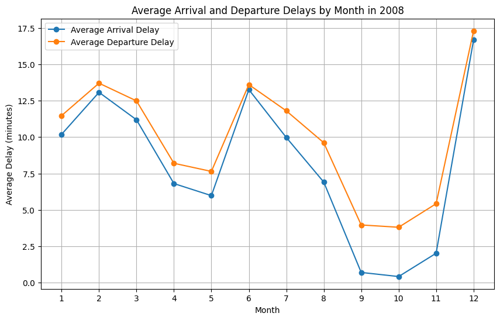

```python
seasonality_2008_pd = seasonality_2008_df.toPandas()

plt.figure(figsize=(10, 6))
plt.plot(seasonality_2008_pd['Month'], seasonality_2008_pd['AvgArrDelay'], label='Average Arrival Delay', marker='o')
plt.plot(seasonality_2008_pd['Month'], seasonality_2008_pd['AvgDepDelay'], label='Average Departure Delay', marker='o')
plt.title('Average Arrival and Departure Delays by Month in 2008')
plt.xlabel('Month')
plt.ylabel('Average Delay (minutes)')
plt.xticks(range(1, 13))
plt.legend()
plt.grid(True)
plt.show()
```